# Getting a feel for and manage your data

In this exercise, we first learn how to get a feel of our data, by looking at the structure of datasets, and then we’re going to focus on how to use the `dplyr` package, exploring functions for data management and transformation. These exercises are (partly) from [DataCamp](https://www.datacamp.com/home) and partly inspired by [R for Data Science](https://r4ds.had.co.nz/transform.html).

# Have a look at the structure of your data

The first thing to do when you get your hands on a new dataset is to **understand its structure**. There are several ways to go about this in R, each of which may reveal different issues with your data that require attention.

In this course, we are only concerned with data that can be expressed in table format (i.e. two dimensions, rows and columns). Tables in R often have the type data.frame. You can check the class of any object in R with the *class()* function.

Once you know that you are dealing with tabular data, you may also want to get a quick feel for the contents of your data. Before printing the entire dataset to the console, it’s probably worth knowing how many rows and columns there are. The *dim()* command tells you this.

## Instructions

I provided you a dataset called *captures.csv*. The data provide information on snow vole captures

- Check the class of captures
- Find the dimensions of captures
- Print the captures column names

```
# View the column names of captures
names(captures)
```

```
 [1] "animal_id"     "capture_id"    "data"          "dawn"          "occasion"
 [6] "trap_id"       "chip"          "recapture"     "furmark"       "weight_g"
[11] "sex"           "age"           "repr_status"   "footlength_mm" "year"
[16] "month"         "DOY"           "session"       "notes"
```

# Viewing the structure of your data

Since *captures* doesn’t have a huge number of columns, you can view a quick snapshot of your data using the *str()* (for structure) command. In addition to the class and dimensions of your entire dataset, *str()* will tell you the class of each variable and give you a preview of its contents.

You can use the *summary()* command to get a better feel for how your data are distributed, which may reveal unusual or extreme values, unexpected missing data, etc. For numeric variables, this means looking at means, quartiles (including the median), and extreme values. For character or factor variables, you may be curious about the number of times each value appears in the data (i.e. counts), which *summary()* also reveals.

## Instructions

- View the structure of *captures* using the traditional method
- Look at a *summary()* of *captures*

```
# View a summary of captures
summary(captures)
```

```
   animal_id       capture_id      data              dawn            occasion
 Min.   : 1.00   Min.   :  1   Length:133         Mode :logical   Min.   : 1.00
 1st Qu.: 6.00   1st Qu.: 34   Class :character   FALSE:53        1st Qu.: 6.00
 Median :11.00   Median : 67   Mode  :character   TRUE :80        Median : 9.00
 Mean   :21.35   Mean   : 67                                      Mean   :10.46
 3rd Qu.:36.00   3rd Qu.:100                                      3rd Qu.:15.00
 Max.   :99.00   Max.   :133                                      Max.   :23.00

    trap_id           chip          recapture           furmark             weight_g
 Min.   : 2.00   Min.   :1310363   Length:133         Length:133         Min.   :14.00
 1st Qu.:18.00   1st Qu.:1313062   Class :character   Class :character   1st Qu.:22.50
 Median :34.00   Median :1314195   Mode  :character   Mode  :character   Median :29.00
 Mean   :35.73   Mean   :1314161                                         Mean   :29.83
 3rd Qu.:55.00   3rd Qu.:1314797                                         3rd Qu.:37.00
 Max.   :74.00   Max.   :1317018                                         Max.   :46.00
                 NA's   :59                                              NA's   :14
     sex                age            repr_status        footlength_mm      year
 Length:133         Length:133         Length:133         Min.   :16    Min.   :2015
 Class :character   Class :character   Class :character   1st Qu.:18    1st Qu.:2015
 Mode  :character   Mode  :character   Mode  :character   Median :18    Median :2015
                                                          Mean   :19    Mean   :2015
                                                          3rd Qu.:19    3rd Qu.:2015
                                                          Max.   :78    Max.   :2015
                                                          NA's   :16
     month           DOY          session             notes
 Min.   :7.00   Min.   :194.0   Length:133         Length:133
 1st Qu.:7.00   1st Qu.:202.0   Class :character   Class :character
 Median :8.00   Median :240.0   Mode  :character   Mode  :character
 Mean   :7.85   Mean   :227.8
 3rd Qu.:8.00   3rd Qu.:242.0
 Max.   :9.00   Max.   :249.0
```

# Looking at your data

You can look at all the summaries you want, but at the end of the day, there is no substitute for looking at your data – either in raw table form or by plotting it.

The most basic way to look at your data in R is by printing it to the console. As you may know from experience, the *print()* command is not even necessary; you can just type the name of the object. The downside to this option is that R will attempt to print the entire dataset, which can be a nuisance if the dataset is too large.

One way around this is to use the *head()* and *tail()* commands, which only display the first and last 6 rows of data, respectively. You can view more (or fewer) rows by providing as a second argument to the function the number of rows you wish to view. These functions provide a useful method for quickly getting a sense of your data without overly cluttering the console.

Finally, one of the best ways to understand data is to plot them. For the moment, we will use the functions *hist()* and *plot()* to produce an histogram of one variable in the dataset, and to plot one variable against another, respectively.

## Instructions

- Print the full dataset to the console (you don’t need *print()* to do this)
- View the first 6 rows of captures
- View the first 15 rows of captures
- View the last 6 rows of captures
- View the last 10 rows of captures
- Produce an histogram of the weight of the animals (*weight_g*)
- Plot *capture_id* (an identification number for the capture events) against the day of the year (*DOY*)

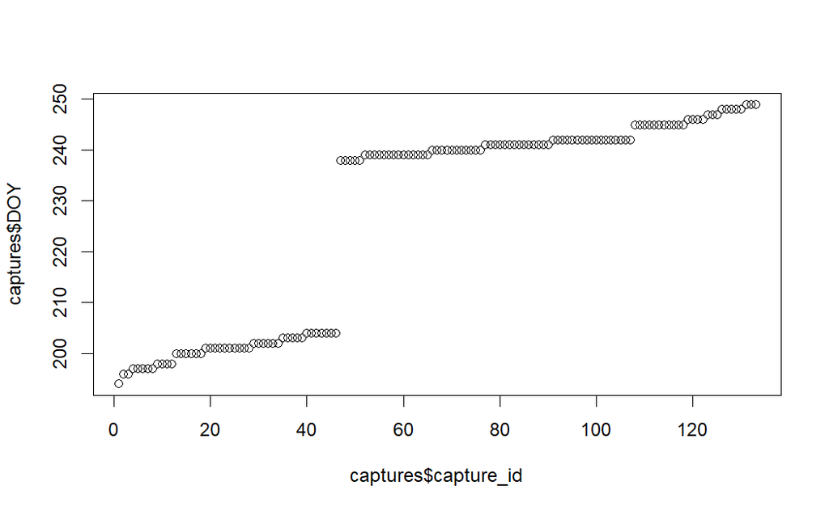

# Data manipulation - the four fundamental verbs

Data manipulation includes variable-by-variable transformation (e.g. log, or sqrt), as well as aggregation, filtering and reordering.

For data manipulation, we can use function from the *base* package, but here we rather focus on the functions from the additional *dplyr* package.

[output not shown]

[output not shown]

[output not shown]

[output not shown]

[output not shown]

[output not shown]

[output not shown]

[output not shown]

[output not shown]

[output not shown]

[output not shown]

[output not shown]

[output not shown]

[output not shown]

[output not shown]

[output not shown]

[output not shown]

[output not shown]

[output not shown]

[output not shown]

[output not shown]